# DATA607_Project2

```r
library(tidyverse)
library(lubridate)
```

## Dataset 1 - Populous States

```r
library(tidyverse)

population <- read_csv("census_top10_states_2022_untidy.csv")
head(population)
```

```
## # A tibble: 6 × 5
##    Rank `Geographic Area`
##   <dbl> <chr>
## 1     1 California
## 2     2 Texas
## 3     3 Florida
## 4     4 New York
## 5     5 Pennsylvania
## 6     6 Illinois
## # ℹ 3 more variables:
## #   `April 1, 2020 (Estimates Base)` <dbl>,
## #   `July 1, 2021` <dbl>,
## #   `July 1, 2022` <dbl>
```

```r
glimpse(population)
```

```
## Rows: 10
## Columns: 5
## $ Rank                             <dbl> 1,…
## $ `Geographic Area`                <chr> "C…
## $ `April 1, 2020 (Estimates Base)` <dbl> 39…
## $ `July 1, 2021`                   <dbl> 39…
## $ `July 1, 2022`                   <dbl> 39…
```

```r
# Convert population data from wide to long format
population_long <- population %>%
  pivot_longer(
    cols = -c(Rank, `Geographic Area`),
    names_to = "Year",
    values_to = "Population"
  )

# View
head(population_long)
```

```
## # A tibble: 6 × 4
##    Rank `Geographic Area` Year     Population
##   <dbl> <chr>             <chr>         <dbl>
## 1     1 California        April 1…   39538245
## 2     1 California        July 1,…   39142991
## 3     1 California        July 1,…   39029342
## 4     2 Texas             April 1…   29145428
## 5     2 Texas             July 1,…   29558864
## 6     2 Texas             July 1,…   30029572
```

```r
# Calculate population changes from 2020 to 2022
population_change <- population_long %>%
  filter(Year %in% c(
    "April 1, 2020 (Estimates Base)",
    "July 1, 2022"
  )) %>%
  select(`Geographic Area`, Year, Population) %>%
  pivot_wider(
    names_from = Year,
    values_from = Population
  ) %>%
  mutate(
    Population_Change = `July 1, 2022` -
      `April 1, 2020 (Estimates Base)`,
    Percent_Change = round(
      Population_Change /
        `April 1, 2020 (Estimates Base)` * 100, 2
    )
  ) %>%
  arrange(desc(Percent_Change))

# Display results
print(population_change)
```

```
## # A tibble: 10 × 5
##    `Geographic Area` April 1, 2020 (Estimat…¹
##    <chr>                                <dbl>
##  1 Florida                           21538226
##  2 Texas                             29145428
##  3 North Carolina                    10439414
##  4 Georgia                           10711937
##  5 Pennsylvania                      13002689
##  6 Ohio                              11799374
##  7 Michigan                          10077325
##  8 California                        39538245
##  9 Illinois                          12812545
## 10 New York                          20201230
## # ℹ abbreviated name:
## #   ¹`April 1, 2020 (Estimates Base)`
## # ℹ 3 more variables: `July 1, 2022` <dbl>,
## #   Population_Change <dbl>,
## #   Percent_Change <dbl>
```

```r
# Display all columns
print(population_change, width = Inf)
```

```
## # A tibble: 10 × 5
##    `Geographic Area`
##    <chr>
##  1 Florida
##  2 Texas
##  3 North Carolina
##  4 Georgia
##  5 Pennsylvania
##  6 Ohio
##  7 Michigan
##  8 California
##  9 Illinois
## 10 New York
##    `April 1, 2020 (Estimates Base)`
##                               <dbl>
```

[output cut: 34 more lines]

## Results & Conclusions

After changing the populace data from wide to long, I computed the population changes for the top 10 most populous states between April 2020 and July 2022.

Florida had the greatest percent increase with 3.28%, rigth before Texas at 3.03%. However, Texas had the biggest numerical increase, getting about 884,000 residents.

New York seemed to have experienced the biggest percent decrease at 2.59 %, which equated to a loss of 524,000 residents. California and illinois also faced apparent population declines.

## Dataset 2: US Average Tuition (2004–2016)

```r
# Dataset 2: US Average Tuition

tuition <- read_csv("us_avg_tuition(Table 5).csv")
# Inspect the dataset
head(tuition)
```

```
## # A tibble: 6 × 13
##   State      `2004-05` `2005-06` `2006-07`
##   <chr>      <chr>     <chr>     <chr>
## 1 Alabama    $5,683    $5,841    $5,753
## 2 Alaska     $4,328    $4,633    $4,919
## 3 Arizona    $5,138    $5,416    $5,481
## 4 Arkansas   $5,772    $6,082    $6,232
## 5 California $5,286    $5,528    $5,335
## 6 Colorado   $4,704    $5,407    $5,596
## # ℹ 9 more variables: `2007-08` <chr>,
## #   `2008-09` <chr>, `2009-10` <chr>,
## #   `2010-11` <chr>, `2011-12` <chr>,
## #   `2012-13` <chr>, `2013-14` <chr>,
## #   `2014-15` <chr>, `2015-16` <chr>
```

```r
glimpse(tuition)
```

```
## Rows: 50
## Columns: 13
## $ State     <chr> "Alabama", "Alaska", "Ari…
## $ `2004-05` <chr> "$5,683", "$4,328", "$5,1…
## $ `2005-06` <chr> "$5,841", "$4,633", "$5,4…
## $ `2006-07` <chr> "$5,753", "$4,919", "$5,4…
## $ `2007-08` <chr> "$6,008", "$5,070", "$5,6…
## $ `2008-09` <chr> "$6,475", "$5,075", "$6,0…
## $ `2009-10` <chr> "$7,189", "$5,455", "$7,2…
## $ `2010-11` <chr> "$8,071", "$5,759", "$8,8…
## $ `2011-12` <chr> "$8,452", "$5,762", "$9,9…
## $ `2012-13` <chr> "$9,098", "$6,026", "$10,…
## $ `2013-14` <chr> "$9,359", "$6,012", "$10,…
## $ `2014-15` <chr> "$9,496", "$6,149", "$10,…
## $ `2015-16` <chr> "$9,751", "$6,571", "$10,…
```

```r
# Check missing values
colSums(is.na(tuition))
```

```
##   State 2004-05 2005-06 2006-07 2007-08
##       0       0       0       0       0
## 2008-09 2009-10 2010-11 2011-12 2012-13
##       0       0       0       0       0
## 2013-14 2014-15 2015-16
##       0       0       0
```

```r
names(tuition)
```

```
##  [1] "State"   "2004-05" "2005-06" "2006-07"
##  [5] "2007-08" "2008-09" "2009-10" "2010-11"
##  [9] "2011-12" "2012-13" "2013-14" "2014-15"
## [13] "2015-16"
```

```r
# Transform from wide to long format
tuition_long <- tuition %>%
  pivot_longer(
    cols = -State,
    names_to = "Academic_Year",
    values_to = "Tuition"
  ) %>%
  mutate(
    Tuition = readr::parse_number(as.character(Tuition))
  )

# Check transformed data
head(tuition_long)
```

```
## # A tibble: 6 × 3
##   State   Academic_Year Tuition
##   <chr>   <chr>           <dbl>
## 1 Alabama 2004-05          5683
## 2 Alabama 2005-06          5841
## 3 Alabama 2006-07          5753
## 4 Alabama 2007-08          6008
## 5 Alabama 2008-09          6475
## 6 Alabama 2009-10          7189
```

```r
# Average tuition by state across all years
state_avg <- tuition_long %>%
  group_by(State) %>%
  summarise(
    Average_Tuition = round(mean(Tuition, na.rm = TRUE), 2),
    .groups = "drop"
  ) %>%
  arrange(desc(Average_Tuition))

print(state_avg, n = 10)
```

```
## # A tibble: 50 × 2
##    State          Average_Tuition
##    <chr>                    <dbl>
##  1 Vermont                 13067.
##  2 New Hampshire           12781.
##  3 New Jersey              12054.
##  4 Pennsylvania            11970
##  5 Illinois                11228.
##  6 Michigan                10477
##  7 South Carolina          10377.
##  8 Delaware                10099.
##  9 Massachusetts           10058.
## 10 Ohio                     9942.
## # ℹ 40 more rows
```

```r
# Highest tuition states in 2015-16
highest_tuition <- tuition_long %>%
  filter(Academic_Year == "2015-16") %>%
  arrange(desc(Tuition))

print(head(highest_tuition, 10))
```

```
## # A tibble: 10 × 3
##    State          Academic_Year Tuition
##    <chr>          <chr>           <dbl>
##  1 New Hampshire  2015-16         15160
##  2 Vermont        2015-16         14993
##  3 Pennsylvania   2015-16         13395
##  4 New Jersey     2015-16         13303
##  5 Illinois       2015-16         13189
##  6 Michigan       2015-16         11991
##  7 Virginia       2015-16         11819
##  8 South Carolina 2015-16         11816
##  9 Delaware       2015-16         11676
## 10 Massachusetts  2015-16         11588
```

```r
# Compare tuition in the first and last years
tuition_change <- tuition_long %>%
  filter(Academic_Year %in% c("2004-05", "2015-16")) %>%
  pivot_wider(
    names_from = Academic_Year,
    values_from = Tuition
  ) %>%
  mutate(
    Change = `2015-16` - `2004-05`,
    Percent_Change = round(Change / `2004-05` * 100, 2)
  ) %>%
  arrange(desc(Percent_Change))

print(tuition_change, n = 10)
```

```
## # A tibble: 50 × 5
##    State      `2004-05` `2015-16` Change
##    <chr>          <dbl>     <dbl>  <dbl>
##  1 Hawaii          4267     10175   5908
##  2 Colorado        4704      9748   5044
##  3 Arizona         5138     10646   5508
##  4 Georgia         4298      8447   4149
##  5 Nevada          3621      6667   3046
##  6 Louisiana       4453      7871   3418
##  7 California      5286      9270   3984
##  8 Alabama         5683      9751   4068
##  9 Tennessee       5426      9263   3837
## 10 Kentucky        5640      9567   3927
## # ℹ 40 more rows
## # ℹ 1 more variable: Percent_Change <dbl>
```

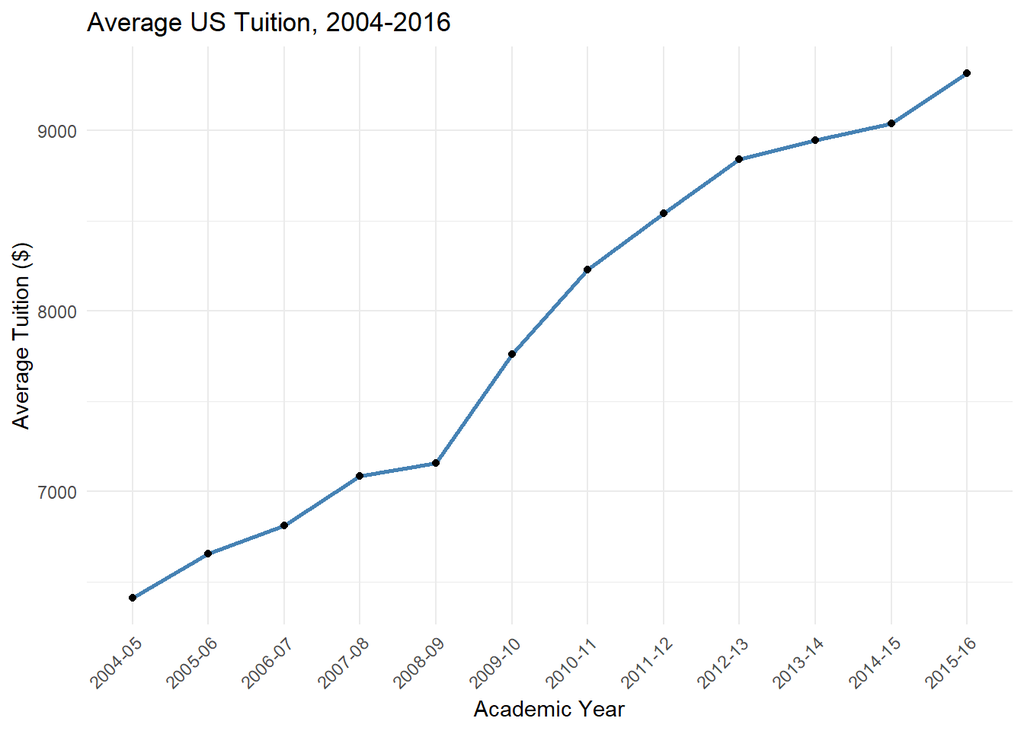

```r
# Average tuition across states by academic year
yearly_tuition <- tuition_long %>%
  group_by(Academic_Year) %>%
  summarise(
    Average_Tuition = mean(Tuition, na.rm = TRUE),
    .groups = "drop"
  )

# Plot tuition trends
ggplot(yearly_tuition,
       aes(x = Academic_Year, y = Average_Tuition, group = 1)) +
  geom_line(color = "steelblue", linewidth = 1) +
  geom_point() +
  labs(
    title = "Average US Tuition, 2004-2016",
    x = "Academic Year",
    y = "Average Tuition ($)"
  ) +
  theme_minimal() +
  theme(axis.text.x = element_text(angle = 45, hjust = 1))
```

```r
head(state_avg, 5)
```

```
## # A tibble: 5 × 2
##   State         Average_Tuition
##   <chr>                   <dbl>
## 1 Vermont                13067.
## 2 New Hampshire          12781.
## 3 New Jersey             12054.
## 4 Pennsylvania           11970
## 5 Illinois               11228.
```

```r
head(tuition_change, 5)
```

```
## # A tibble: 5 × 5
##   State    `2004-05` `2015-16` Change
##   <chr>        <dbl>     <dbl>  <dbl>
## 1 Hawaii        4267     10175   5908
## 2 Colorado      4704      9748   5044
## 3 Arizona       5138     10646   5508
## 4 Georgia       4298      8447   4149
## 5 Nevada        3621      6667   3046
## # ℹ 1 more variable: Percent_Change <dbl>
```

```r
tail(tuition_change, 5)
```

```
## # A tibble: 5 × 5
##   State    `2004-05` `2015-16` Change
##   <chr>        <dbl>     <dbl>  <dbl>
## 1 Iowa          6813      7877   1064
## 2 Missouri      7477      8564   1087
## 3 Montana       5630      6351    721
## 4 Maryland      8531      9163    632
## 5 Ohio         10378     10196   -182
## # ℹ 1 more variable: Percent_Change <dbl>
```

## Results & Conclusions

After transforming the tuition dataset from wide to long, I was able to compare every state’s tuition throughout academic years.

Seeing the results, Iowa faced a 15.62% increase between 2004-05 and 2015-16, while Missouri went up by 14.54% and Montana went up by 12.81%. Maryland also saw an upwards of 7.41%.

Ohio showcased a 1.75% decrease over the same period. This insinuates that tuiton trends were not uniform throughout the states.

## Dataset 3: Business Costs and Revenue

```r
# Dataset 3: Business Costs and Revenue

business <- read_csv("5A_BusinessCostsRevenue.csv")
# Inspect structure
head(business)
```

```
## # A tibble: 5 × 14
##   Location Name   `Jan Cost` `Jan Revenue`
##   <chr>    <chr>       <dbl>         <dbl>
## 1 Boston   Bobby       29000         50000
## 2 Chicago  Denise      41000         45000
## 3 LA       Ethan       30500         39000
## 4 New York April       19000         31500
## 5 Dallas   Emma        38000         42000
## # ℹ 10 more variables: `Feb Cost (k)` <dbl>,
## #   `Feb Revenue` <dbl>,
## #   `March Cost (k)` <dbl>,
## #   `March Revenue` <dbl>, April_Cost <dbl>,
## #   April_revenue <dbl>, `May Cost` <dbl>,
## #   `may revenue` <dbl>, `June Cost` <dbl>,
## #   `June Revenue` <dbl>
```

```r
names(business)
```

```
##  [1] "Location"       "Name"
##  [3] "Jan Cost"       "Jan Revenue"
##  [5] "Feb Cost (k)"   "Feb Revenue"
##  [7] "March Cost (k)" "March Revenue"
##  [9] "April_Cost"     "April_revenue"
## [11] "May Cost"       "may revenue"
## [13] "June Cost"      "June Revenue"
```

```r
glimpse(business)
```

```
## Rows: 5
## Columns: 14
## $ Location         <chr> "Boston", "Chicago…
## $ Name             <chr> "Bobby", "Denise",…
## $ `Jan Cost`       <dbl> 29000, 41000, 3050…
## $ `Jan Revenue`    <dbl> 50000, 45000, 3900…
## $ `Feb Cost (k)`   <dbl> 50.0, 50.6, 31.0, …
## $ `Feb Revenue`    <dbl> 52000, 34000, 3800…
## $ `March Cost (k)` <dbl> 40, 14, 60, 28, 31
## $ `March Revenue`  <dbl> 48000, 41000, 6500…
## $ April_Cost       <dbl> 50000, 56000, 6000…
## $ April_revenue    <dbl> 53000, 34000, 5800…
## $ `May Cost`       <dbl> 25000, 14000, 3600…
## $ `may revenue`    <dbl> 6150000, 21000, 37…
## $ `June Cost`      <dbl> 45000, 38000, 6200…
## $ `June Revenue`   <dbl> 44000, 46000, 5500…
```

```r
# Standardize column names
business_clean <- business %>%
  rename(
    Jan_Cost = `Jan Cost`,
    Jan_Revenue = `Jan Revenue`,
    Feb_Cost = `Feb Cost (k)`,
    Feb_Revenue = `Feb Revenue`,
    March_Cost = `March Cost (k)`,
    March_Revenue = `March Revenue`,
    April_Cost = April_Cost,
    April_Revenue = April_revenue,
    May_Cost = `May Cost`,
    May_Revenue = `may revenue`,
    June_Cost = `June Cost`,
    June_Revenue = `June Revenue`
  ) %>%
  mutate(
    Feb_Cost = Feb_Cost * 1000,
    March_Cost = March_Cost * 1000
  )

# Convert wide data into long format
business_long <- business_clean %>%
  pivot_longer(
    cols = -c(Location, Name),
    names_to = c("Month", ".value"),
    names_sep = "_"
  ) %>%
  mutate(
    Month = factor(
      Month,
      levels = c("Jan", "Feb", "March",
                 "April", "May", "June")
    ),
    Profit = Revenue - Cost
  )

# Inspect transformed data
print(business_long, n = 30)
```

```
## # A tibble: 30 × 6
##    Location Name  Month  Cost Revenue  Profit
##    <chr>    <chr> <fct> <dbl>   <dbl>   <dbl>
##  1 Boston   Bobby Jan   29000   50000   21000
##  2 Boston   Bobby Feb   50000   52000    2000
##  3 Boston   Bobby March 40000   48000    8000
##  4 Boston   Bobby April 50000   53000    3000
##  5 Boston   Bobby May   25000 6150000 6125000
##  6 Boston   Bobby June  45000   44000   -1000
##  7 Chicago  Deni… Jan   41000   45000    4000
##  8 Chicago  Deni… Feb   50600   34000  -16600
##  9 Chicago  Deni… March 14000   41000   27000
## 10 Chicago  Deni… April 56000   34000  -22000
## 11 Chicago  Deni… May   14000   21000    7000
## 12 Chicago  Deni… June  38000   46000    8000
```

[output cut: 18 more lines]

```r
# Calculate monthly business performance
monthly_summary <- business_long %>%
  group_by(Month) %>%
  summarise(
    Total_Cost = sum(Cost, na.rm = TRUE),
    Total_Revenue = sum(Revenue, na.rm = TRUE),
    Total_Profit = sum(Profit, na.rm = TRUE),
    .groups = "drop"
  )

print(monthly_summary)
```

```
## # A tibble: 6 × 4
##   Month Total_Cost Total_Revenue Total_Profit
##   <fct>      <dbl>         <dbl>        <dbl>
## 1 Jan       157500        207500        50000
## 2 Feb       169600        213000        43400
## 3 March     173000        222000        49000
## 4 April     231000        209000       -22000
## 5 May       136000       6281500      6145500
## 6 June      194000        203000         9000
```

## Results & Conclusions

After cleaning the business dataset via standardization of column names and dollar conversions across february and March, I was able to restructure the data into long form and compute profits by reducing costs from revenue.

The results show that January produced 50,000 in profit, then came March with 49,000 and February with 43,000. April was the single month with a staggering loss of 22,000.

The sudden profit gain of 6, 145, 000 in May showed an unusual turnout that may need to be studied before coming towards conclusive business decision.

Ultimately, reshaping the dataset facilitated the process of comparing monthly performance and pinpont unusual observations that can affect analysis.